# Predicting “How Well” People Perform Dumbbell Lifts

Yu-Zhen Tu

2017/5/23

## Background

People often quantify *how much* they perform exercises, but little investigation focuses on *how well* they do exercises. This dataset is aimed to study how our body parts move when doing dumbbell lifts correctly. Further information about the data can be found in “Weight Lifting Exercises Dataset” section of the data source page below.

## Importing Data

```r
training <- read.csv("https://d396qusza40orc.cloudfront.net/predmachlearn/pml-training.csv")[,-1]
testing <- read.csv("https://d396qusza40orc.cloudfront.net/predmachlearn/pml-testing.csv")[,-1]
str(training)
```

```
'data.frame':   19622 obs. of  159 variables:
 $ user_name               : Factor w/ 6 levels "adelmo","carlitos",..: 2 2 2 2 2 2 2 2 2 2 ...
 $ raw_timestamp_part_1    : int  1323084231 1323084231 1323084231 1323084232 1323084232 1323084232 1323084232 1323084232 1323084232 1323084232 ...
 $ raw_timestamp_part_2    : int  788290 808298 820366 120339 196328 304277 368296 440390 484323 484434 ...
 $ cvtd_timestamp          : Factor w/ 20 levels "02/12/2011 13:32",..: 9 9 9 9 9 9 9 9 9 9 ...
 $ new_window              : Factor w/ 2 levels "no","yes": 1 1 1 1 1 1 1 1 1 1 ...
 $ num_window              : int  11 11 11 12 12 12 12 12 12 12 ...
 $ roll_belt               : num  1.41 1.41 1.42 1.48 1.48 1.45 1.42 1.42 1.43 1.45 ...
 $ pitch_belt              : num  8.07 8.07 8.07 8.05 8.07 8.06 8.09 8.13 8.16 8.17 ...
 $ yaw_belt                : num  -94.4 -94.4 -94.4 -94.4 -94.4 -94.4 -94.4 -94.4 -94.4 -94.4 ...
 $ total_accel_belt        : int  3 3 3 3 3 3 3 3 3 3 ...
 $ kurtosis_roll_belt      : Factor w/ 397 levels "","-0.016850",..: 1 1 1 1 1 1 1 1 1 1 ...
 $ kurtosis_picth_belt     : Factor w/ 317 levels "","-0.021887",..: 1 1 1 1 1 1 1 1 1 1 ...
 $ kurtosis_yaw_belt       : Factor w/ 2 levels "","#DIV/0!": 1 1 1 1 1 1 1 1 1 1 ...
 $ skewness_roll_belt      : Factor w/ 395 levels "","-0.003095",..: 1 1 1 1 1 1 1 1 1 1 ...
```

[output cut: 86 more lines]

```r
str(testing)
```

```
'data.frame':   20 obs. of  159 variables:
 $ user_name               : Factor w/ 6 levels "adelmo","carlitos",..: 6 5 5 1 4 5 5 5 2 3 ...
 $ raw_timestamp_part_1    : int  1323095002 1322673067 1322673075 1322832789 1322489635 1322673149 1322673128 1322673076 1323084240 1322837822 ...
 $ raw_timestamp_part_2    : int  868349 778725 342967 560311 814776 510661 766645 54671 916313 384285 ...
 $ cvtd_timestamp          : Factor w/ 11 levels "02/12/2011 13:33",..: 5 10 10 1 6 11 11 10 3 2 ...
 $ new_window              : Factor w/ 1 level "no": 1 1 1 1 1 1 1 1 1 1 ...
 $ num_window              : int  74 431 439 194 235 504 485 440 323 664 ...
 $ roll_belt               : num  123 1.02 0.87 125 1.35 -5.92 1.2 0.43 0.93 114 ...
 $ pitch_belt              : num  27 4.87 1.82 -41.6 3.33 1.59 4.44 4.15 6.72 22.4 ...
 $ yaw_belt                : num  -4.75 -88.9 -88.5 162 -88.6 -87.7 -87.3 -88.5 -93.7 -13.1 ...
 $ total_accel_belt        : int  20 4 5 17 3 4 4 4 4 18 ...
 $ kurtosis_roll_belt      : logi  NA NA NA NA NA NA ...
 $ kurtosis_picth_belt     : logi  NA NA NA NA NA NA ...
 $ kurtosis_yaw_belt       : logi  NA NA NA NA NA NA ...
 $ skewness_roll_belt      : logi  NA NA NA NA NA NA ...
```

[output cut: 86 more lines]

## Data Analyses with Machine Learning Techniques

### Variable selection

The “classe” variable in the training set indicates five types of doing dumbbell lifts, where only type A stands for exactly correct way and the other four types stand for common mistakes.

Here I would like to select pitch/roll/yaw degrees of arm/forearm/dumbbell/belt to discriminate the five types, because I think how the body parts move determines whether people are doing exercises correctly.

### Support vector machine (SVM)

```r
library(e1071)
# Create SVM
# Method: C-classification and radial kernal
# Parameters (default values): cost = 1 and gamma = (data dimension)^-1
svm_model <- svm(classe ~ pitch_arm + pitch_forearm + pitch_dumbbell + pitch_belt +
                   roll_arm + roll_forearm + roll_dumbbell + roll_belt +
                   yaw_arm + yaw_forearm + yaw_dumbbell + yaw_belt, data = training,
                 scale = FALSE, cross = 10)
summary(svm_model)
```

```
Call:
svm(formula = classe ~ pitch_arm + pitch_forearm + pitch_dumbbell +
    pitch_belt + roll_arm + roll_forearm + roll_dumbbell + roll_belt +
    yaw_arm + yaw_forearm + yaw_dumbbell + yaw_belt, data = training,
    cross = 10, scale = FALSE)


Parameters:
   SVM-Type:  C-classification
 SVM-Kernel:  radial
       cost:  1
      gamma:  0.08333333

Number of Support Vectors:  18403

 ( 4713 3772 3327 3066 3525 )


Number of Classes:  5

Levels:
 A B C D E

10-fold cross-validation on training data:

Total Accuracy: 44.83233
Single Accuracies:
 44.44444 44.69929 44.54638 43.42508 45.38971 47.19674 44.85219 44.64832 43.52701 45.59348
```

```r
# predict(svm_model, testing) gives me factor(0)
predict(svm_model, testing[, match(c("pitch_arm", "pitch_forearm", "pitch_dumbbell", "pitch_belt", "roll_arm", "roll_forearm", "roll_dumbbell", "roll_belt", "yaw_arm", "yaw_forearm", "yaw_dumbbell", "yaw_belt"), names(testing))])
```

```
 1  2  3  4  5  6  7  8  9 10 11 12 13 14 15 16 17 18 19 20
 A  A  B  A  A  A  D  B  A  A  A  C  A  A  A  A  A  A  A  A
Levels: A B C D E
```

### Decision tree

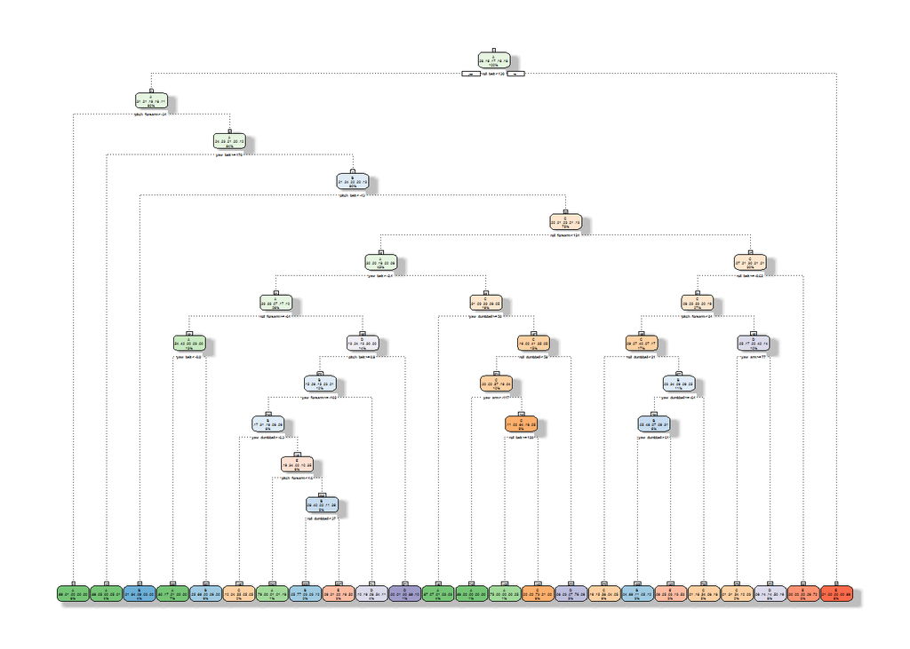

```r
library(rpart)
library(rattle)
# Create a decision tree
rpart_model <- rpart(classe ~
                       pitch_arm + pitch_forearm + pitch_dumbbell + pitch_belt +
                       roll_arm + roll_forearm + roll_dumbbell + roll_belt +
                       yaw_arm + yaw_forearm + yaw_dumbbell + yaw_belt,
                     data = training)
fancyRpartPlot(rpart_model, sub = NULL)
```

```r
predict(rpart_model, testing)
```

```
             A           B           C          D          E
1  0.005221932 0.310704961 0.537859008 0.11749347 0.02872063
2  0.823299453 0.168100078 0.008600469 0.00000000 0.00000000
3  0.006128703 0.183861083 0.543411645 0.08478039 0.18181818
4  0.977477477 0.022522523 0.000000000 0.00000000 0.00000000
5  0.115303983 0.243186583 0.549266247 0.04612159 0.04612159
6  0.000000000 0.016453382 0.000000000 0.26325411 0.72029250
7  0.061690315 0.137569402 0.142504627 0.49722394 0.16101172
8  0.115303983 0.243186583 0.549266247 0.04612159 0.04612159
9  0.993662864 0.006337136 0.000000000 0.00000000 0.00000000
10 0.823299453 0.168100078 0.008600469 0.00000000 0.00000000
11 0.044905009 0.687392055 0.105354059 0.04663212 0.11571675
12 0.006128703 0.183861083 0.543411645 0.08478039 0.18181818
13 0.187797147 0.152931854 0.577654517 0.03565769 0.04595880
14 0.993662864 0.006337136 0.000000000 0.00000000 0.00000000
15 0.061690315 0.137569402 0.142504627 0.49722394 0.16101172
16 0.091054313 0.210862620 0.017571885 0.15814696 0.52236422
17 0.867346939 0.065051020 0.005102041 0.02933673 0.03316327
18 0.104786546 0.160413972 0.078913325 0.54333765 0.11254851
19 0.104786546 0.160413972 0.078913325 0.54333765 0.11254851
20 0.044905009 0.687392055 0.105354059 0.04663212 0.11571675
```

### Random forests

```r
library(randomForest)
# Create random forests
# Parameters (default values): mtry = sqrt(p)
rf_model <- randomForest(classe ~
                           pitch_arm + pitch_forearm + pitch_dumbbell + pitch_belt +
                           roll_arm + roll_forearm + roll_dumbbell + roll_belt +
                           yaw_arm + yaw_forearm + yaw_dumbbell + yaw_belt,
                         data = training)
rf_model
```

```
Call:
 randomForest(formula = classe ~ pitch_arm + pitch_forearm + pitch_dumbbell +      pitch_belt + roll_arm + roll_forearm + roll_dumbbell + roll_belt +      yaw_arm + yaw_forearm + yaw_dumbbell + yaw_belt, data = training)
               Type of random forest: classification
                     Number of trees: 500
No. of variables tried at each split: 3

        OOB estimate of  error rate: 0.84%
Confusion matrix:
     A    B    C    D    E class.error
A 5568    8    0    3    1 0.002150538
B   17 3732   44    3    1 0.017118778
C    0   19 3378   23    2 0.012857978
D    2    4   13 3195    2 0.006529851
E    0    5   12    5 3585 0.006099251
```

```r
predict(rf_model, testing)
```

```
 1  2  3  4  5  6  7  8  9 10 11 12 13 14 15 16 17 18 19 20
 B  A  B  A  A  E  D  B  A  A  B  C  B  A  E  E  A  B  B  B
Levels: A B C D E
```

```r
# Cross-validation for feature selection
rf_cv <- rfcv(training[,match(c("pitch_arm", "pitch_forearm", "pitch_dumbbell", "pitch_belt", "roll_arm", "roll_forearm", "roll_dumbbell", "roll_belt", "yaw_arm", "yaw_forearm", "yaw_dumbbell", "yaw_belt"), names(training))], training$classe, 10)
rf_cv$error.cv
```

```
         12           6           3           1
0.008867598 0.026246050 0.110029559 0.440424014
```

## General Discussion

### Cross-validation and expected out-of-sample errors

The `svm` function in e1071 package provides an argument for k-fold cross-validation of a SVM model. According to the result of 10-fold validation, the accuracy is about 45%, which is fairly good compared with a random guess - 1/5, 20%. However, the expected errors would be over 50%, and more than half of the predicted results would be incorrect.

Theoretically, the best SVM parameters can be found with `tune`. However, the following codes cost so much computation resource for my laptop that the mission was not completed in ten hours. I believe the accuracy of SVM would be improved if I tuned “gamma” and “cost” appropriately.

```r
svm_tune <- tune(svm,
                 classe ~ pitch_arm + pitch_forearm + pitch_dumbbell + pitch_belt +
                   roll_arm + roll_forearm + roll_dumbbell + roll_belt +
                   yaw_arm + yaw_forearm + yaw_dumbbell + yaw_belt,
                 scale = FALSE,
                 ranges = list(gamma = seq(0, 1, 0.05), cost = 2^(-1:5)),
                 data = training[, match(c("classe", "pitch_arm", "pitch_forearm", "pitch_dumbbell", "pitch_belt", "roll_arm", "roll_forearm", "roll_dumbbell", "roll_belt", "yaw_arm", "yaw_forearm", "yaw_dumbbell", "yaw_belt"), names(training))])
```

For decision tree, the predictions seem poor. The tree cannot generate some nodes separating the training data clearly. Identified categories appear in both sides of some nodes.

If one tree is not enough, how about a forest? I used `rfcv` to perform cross-validation for feature selection of the built random forests. The errors show that, when using my selected 12 variables, the error can be reduced to about 0.009, which is less than 1%. Besides, the error drops remarkably when the used variable number increases from 1, 3, 6, to 12.

### Prediction quality accessment

I selected the random forests model. With that, I got 20/20 correct predictions for testing data.

## Data Source

The data are generously provided by [Groupware@LES](http://groupware.les.inf.puc-rio.br/har).

## Related Published Paper

- Velloso, E.; Bulling, A.; Gellersen, H.; Ugulino, W.; Fuks, H. [Qualitative Activity Recognition of Weight Lifting Exercises](http://groupware.les.inf.puc-rio.br/work.jsf?p1=11201). Proceedings of 4th International Conference in Cooperation with SIGCHI (Augmented Human ’13). Stuttgart, Germany: ACM SIGCHI, 2013.